# Project 6

Daniel Izaguirre

November 17, 2016

# Project 6

## Details

```r
library("ggplot2")
library("dplyr")
```

Analysis of the Iowa Housing data set provided by the Ames Assessor’s Office. The data set is to assess values for individual residential properties sold in Ames, IA from 2006 to 2010.

The data set contains 81 variables and 2930 observations.

This project analyzes 8 variables in total. However only 5 are chosen for their statistical significance for the final multiple regession model. These are produced by other variables in the dataset to help summarise the data. Boxplots are used to visualize the respective variables.

```r
data <- read.csv("IowaHousing.csv")
View(data)
```

### Model 1: By shape of the lot.

This model will need to define the observations which are “regular” and “irregular”. The data set has 3 types of irregular observations that are possible and 1 type of regular observation in regard to the shape of the lot.

```r
shape <- function(n)
{
  if (n == 'Reg')
    return("regular")
  else
    return("irregular")
}
data$Shape <- sapply(data$Lot.Shape, shape)
```

The model’s new variable, Shape, can now be plotted.

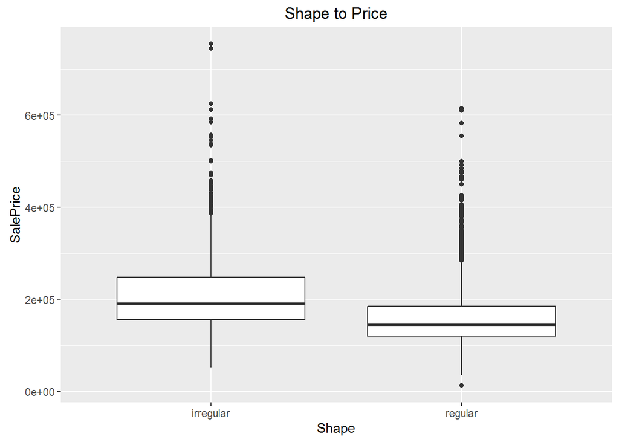

```r
plot1 <- ggplot(data, aes(Shape, SalePrice))
plot1 <- plot1 + geom_boxplot()
plot1 <- plot1 + xlab("Shape")
plot1 <- plot1 + ggtitle("Shape to Price")
plot1
```

The “irregular” shape of a lot has a higher mean price than a “regular” lot.

Now, we can make a model to represent statistical significance of the variable in regard to price with Shape.

```r
priceModel <- lm(SalePrice ~ Shape, data = data)
summary(priceModel)
```

```
##
## Call:
## lm(formula = SalePrice ~ Shape, data = data)
##
## Residuals:
##     Min      1Q  Median      3Q     Max
## -160414  -45664  -18530   27086  542586
##
## Coefficients:
##              Estimate Std. Error t value Pr(>|t|)
## (Intercept)    212414       2329   91.22   <2e-16 ***
## Shaperegular   -49834       2924  -17.05   <2e-16 ***
## ---
## Signif. codes:  0 '***' 0.001 '**' 0.01 '*' 0.05 '.' 0.1 ' ' 1
##
## Residual standard error: 76210 on 2928 degrees of freedom
## Multiple R-squared:  0.09028,    Adjusted R-squared:  0.08997
## F-statistic: 290.6 on 1 and 2928 DF,  p-value: < 2.2e-16
```

```r
#p_value_1 <- summary(priceModel)$coefficients[2,4]
#p_value_1

priceCoef <- priceModel$coefficients
co1 <- round(priceCoef[1],2)
co2 <- round(priceCoef[2],2)
priceModel_r2 <- round(summary(priceModel)$r.squared, digits = 2)*100

fstat <- summary(priceModel)$fstatistic
fstat
```

```
##     value     numdf     dendf
##  290.5618    1.0000 2928.0000
```

The model shows a weak negative correlation for the variables in the multiple regression model.

The model shows a significant p-value for all values. The F-statistic is on 290.56 on 1 to 2928. Additionally, this model has an r-squared value of 9%, which means that 9% of variance in the price of a home is accounted for by the shape of the lot.

Current Linear Regression Equation: $\widehat{SalePrice} = (2.12414\times 10^{5}) + (-4.983355\times 10^{4})*Shape$

For irregular shape, the Shape is 0. This model indicates the mean home price with an irregular shape lot is 2.1241410^{5}. For regular shape, the Shape is 1. This model indicates the mean home price with an irregular shape lot is 1.62580510^{5}.

### Model 2: By the lot’s road access to a main street.

This model will need to define a variable for the observations which have different kinds of road access. The road access variable will defined by “paved” and “unpaved” access to the main street.

```r
road_access <- function(n)
{
  if (n == 'Pave')
    return("paved")
  else
    return("unpaved")
}
data$RoadAccess <- sapply(data$Street, road_access)
```

The model’s new variable, RoadAccess, can now be plotted.

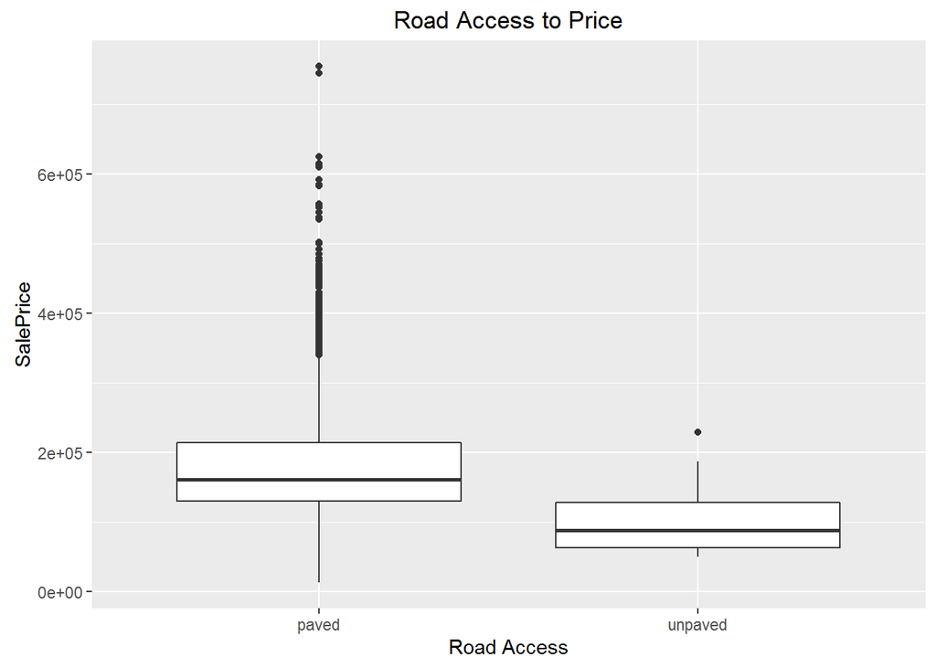

```r
plot2 <- ggplot(data, aes(RoadAccess, SalePrice))
plot2 <- plot2 + geom_boxplot()
plot2 <- plot2 + xlab("Road Access")
plot2 <- plot2 + ggtitle("Road Access to Price")
plot2
```

A “paved” access to a road has a higher mean price than a home with an “unpaved” access to a main road.

Now, we can make a multiple regression model to represent statistical significance of the variables in regard to price.

```r
priceModel <- lm(SalePrice ~ Shape + RoadAccess, data = data)
summary(priceModel)
```

```
##
## Call:
## lm(formula = SalePrice ~ Shape + RoadAccess, data = data)
##
## Residuals:
##     Min      1Q  Median      3Q     Max
## -160606  -45771  -18510   27085  542394
##
## Coefficients:
##                   Estimate Std. Error t value Pr(>|t|)
## (Intercept)         212606       2326  91.403  < 2e-16 ***
## Shaperegular        -49693       2920 -17.021  < 2e-16 ***
## RoadAccessunpaved   -68673      22015  -3.119  0.00183 **
## ---
## Signif. codes:  0 '***' 0.001 '**' 0.01 '*' 0.05 '.' 0.1 ' ' 1
##
## Residual standard error: 76100 on 2927 degrees of freedom
## Multiple R-squared:  0.09329,    Adjusted R-squared:  0.09267
## F-statistic: 150.6 on 2 and 2927 DF,  p-value: < 2.2e-16
```

```r
priceCoef <- priceModel$coefficients
priceCoef
```

```
##       (Intercept)      Shaperegular RoadAccessunpaved
##         212606.36         -49693.44         -68672.95
```

```r
fstat <- summary(priceModel)$fstatistic
fstat
```

```
##     value     numdf     dendf
##  150.5796    2.0000 2927.0000
```

```r
priceModel_r2 <- round(summary(priceModel)$r.squared, digits = 2)*100
priceModel_r2
```

```
## [1] 9
```

The model shows a weak negative correlation in for the variables in the multiple regression model.

The model shows a significant p-value for all values. The F-statistic is on 150.58 on 2 to 2927. Additionally, this model has an r-squared value of 9%, which means that 9% of variance in the price of a home is accounted for by the shape and road access of the lot.

Current Linear Regression Equation: $\widehat{SalePrice} = (2.1260636\times 10^{5}) + (-4.969344\times 10^{4})*Shape + (-6.867295\times 10^{4})*RoadAccess$

The original equation is extended with a new RoadAccess coefficient. When RoadAccess is 0, the mean home price is 2.126063610^{5}. When RoadAccess is 1, the mean home price is 1.439334610^{5}.

### Model 3: By a lot being in a residentialor non-residential area.

This model will need to define the observations which have different kinds of property location. In particular, the new variable will have 2 types of observations, “residential” and “non-residential”.

```r
data$Residential <- ifelse(grepl('R[A-Z]', data$MS.Zoning), "residential", "non-residential")
```

Homes in “nonresidential” areas have a higher mean price than those which reside in a “residential” area.

The model’s new variable, Residential, can now be plotted.

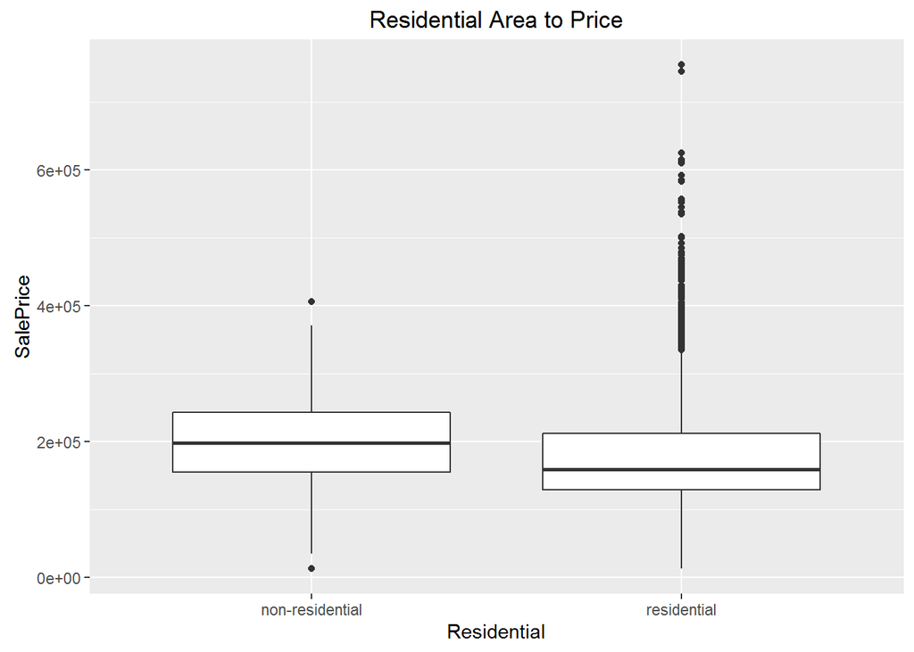

```r
plot3 <- ggplot(data, aes(Residential, SalePrice))
plot3 <- plot3 + geom_boxplot()
plot3 <- plot3 + xlab("Residential")
plot3 <- plot3 + ggtitle("Residential Area to Price")
plot3
```

The homes “non-residential” areas have a higher mean price than homes with in “residential” area.

Now, we can make a multiple regression model to represent statistical significance of the variables in regard to price.

```r
priceModel <- lm(SalePrice ~ Shape + RoadAccess + Residential, data = data)
summary(priceModel)
```

```
##
## Call:
## lm(formula = SalePrice ~ Shape + RoadAccess + Residential, data = data)
##
## Residuals:
##     Min      1Q  Median      3Q     Max
## -170543  -44683  -18508   26934  543317
##
## Coefficients:
##                        Estimate Std. Error t value Pr(>|t|)
## (Intercept)              233818       6277  37.250  < 2e-16 ***
## Shaperegular             -50175       2916 -17.204  < 2e-16 ***
## RoadAccessunpaved        -78456      22133  -3.545 0.000399 ***
## Residentialresidential   -22135       6086  -3.637 0.000281 ***
## ---
## Signif. codes:  0 '***' 0.001 '**' 0.01 '*' 0.05 '.' 0.1 ' ' 1
##
## Residual standard error: 75940 on 2926 degrees of freedom
## Multiple R-squared:  0.09737,    Adjusted R-squared:  0.09645
## F-statistic: 105.2 on 3 and 2926 DF,  p-value: < 2.2e-16
```

```r
priceCoef <- priceModel$coefficients
priceCoef
```

```
##            (Intercept)           Shaperegular      RoadAccessunpaved
##              233817.99              -50175.42              -78455.62
## Residentialresidential
##              -22134.93
```

```r
fstat <- summary(priceModel)$fstatistic
fstat
```

```
##     value     numdf     dendf
##  105.2151    3.0000 2926.0000
```

```r
priceModel_r2 <- round(summary(priceModel)$r.squared, digits = 2)*100
priceModel_r2
```

```
## [1] 10
```

The model shows a weak positive correlation in for the variables in the multiple regression model.

The model shows a significant p-value for all values. The F-statistic is on 105.22 on 3 to 2926. Additionally, this model has an r-squared value of 10%, which means that 10% of variance in the price of a home is accounted for by the shape, road access, and status of residential area of the lot.

Current Linear Regression Equation: $\widehat{SalePrice} = (2.3381799\times 10^{5}) + (-5.017542\times 10^{4})*Shape + (-7.845562\times 10^{4})*RoadAccess + (-2.213493\times 10^{4})*Residential$

The previous model’s equation is extended with the new Residential coefficient. When Residential is 0, the mean price of a home is 2.338179910^{5}. When Residential is 1, the mean price of a home is 2.116830610^{5}

### Model 4: By the quality of materials and finish of the home on the lot.

This model will define a variable which accounts for homes that have been made and finished with quality materials. In general this can be considered overall quality of the home. In particular, the new variable will have 2 types of observations, “good and above” and “average and below”.

```r
quality <- function(n)
{
  if (n >= 7)
    return("good and above")
  else
    return("average and below")
}
data$Quality <- sapply(data$Overall.Qual, quality)
```

The box plot shows that homes with “good and above” finish and quality of materials have a higher mean price as opposed to “average and below”.

The model’s new variable, Quality, can now be plotted.

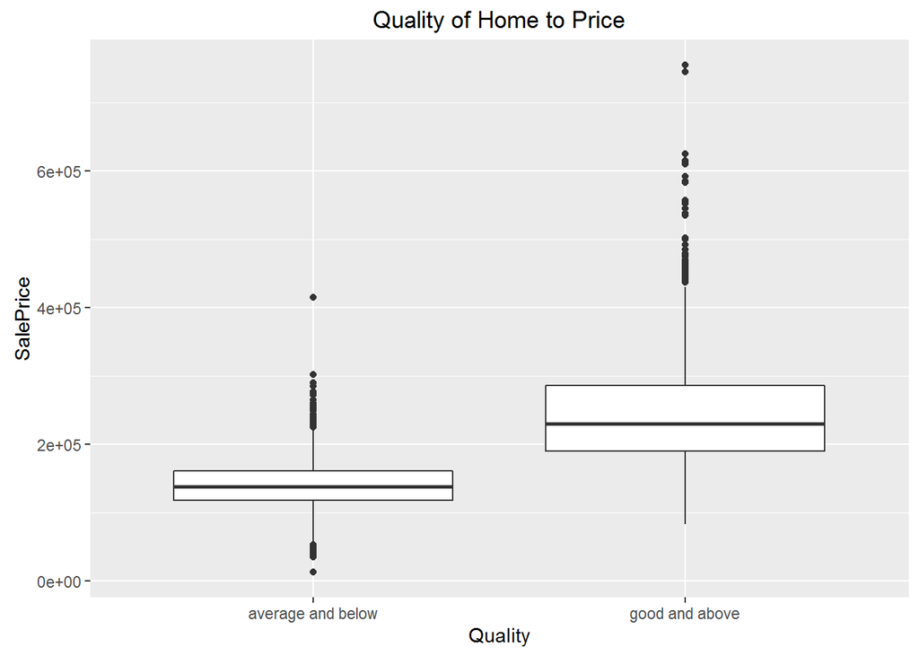

```r
plot4 <- ggplot(data, aes(Quality, SalePrice))
plot4 <- plot4 + geom_boxplot()
plot4 <- plot4 + xlab("Quality")
plot4 <- plot4 + ggtitle("Quality of Home to Price")
plot4
```

Now, we can make a multiple regression model to represent statistical significance of the variables in regard to price.

```r
priceModel <- lm(SalePrice ~ Shape + RoadAccess + Residential + Quality, data = data)
summary(priceModel)
```

```
##
## Call:
## lm(formula = SalePrice ~ Shape + RoadAccess + Residential + Quality,
##     data = data)
##
## Residuals:
##     Min      1Q  Median      3Q     Max
## -166001  -33746   -4746   23153  491499
##
## Coefficients:
##                        Estimate Std. Error t value Pr(>|t|)
## (Intercept)              142698       5267  27.092  < 2e-16 ***
## Shaperegular             -25548       2321 -11.006  < 2e-16 ***
## RoadAccessunpaved        -25172      17148  -1.468  0.14224
## Residentialresidential    16595       4784   3.469  0.00053 ***
## Qualitygood and above    104208       2346  44.423  < 2e-16 ***
## ---
## Signif. codes:  0 '***' 0.001 '**' 0.01 '*' 0.05 '.' 0.1 ' ' 1
##
## Residual standard error: 58690 on 2925 degrees of freedom
## Multiple R-squared:  0.461,  Adjusted R-squared:  0.4603
## F-statistic: 625.4 on 4 and 2925 DF,  p-value: < 2.2e-16
```

```r
p_value_int <- summary(priceModel)$coefficients[3,4]
p_value_int
```

```
## [1] 0.1422372
```

```r
priceCoef <- priceModel$coefficients
priceCoef
```

```
##            (Intercept)           Shaperegular      RoadAccessunpaved
##              142698.09              -25547.90              -25171.50
## Residentialresidential  Qualitygood and above
##               16595.33              104207.65
```

```r
fstat <- summary(priceModel)$fstatistic
fstat
```

```
##     value     numdf     dendf
##  625.4462    4.0000 2925.0000
```

```r
priceModel_r2 <- round(summary(priceModel)$r.squared, digits = 2)*100
priceModel_r2
```

```
## [1] 46
```

The model shows a moderate positive correlation in for the variables in the multiple regression model.

The model shows a significant p-value for all values except RoadAccess (p-value = 0.1422372), thus it must be removed in the next model. The F-statistic is on 625.45 on 4 to 2925. Additionally, this model has an r-squared value of 46%, which means that 46% of variance in the price of a home is accounted for by the shape, road access, status of residential area of the lot, and quality of home.

Current Linear Regression Equation: $\widehat{SalePrice} = (1.4269809\times 10^{5}) + (-2.55479\times 10^{4})*Shape + (-2.51715\times 10^{4})*RoadAccess + (1.659533\times 10^{4})*Residential + (1.0420765\times 10^{5})*Quality$

The previous model’s equation is extended with the new Quality coefficient. When Quality is 0, the mean price of a home is 1.426980910^{5}. When Quality is 1, the mean price of a home is 2.469057410^{5}.

### Model 5: By condition of the house at sell

This model will define a variable which accounts for a home’s physical and aesthetic condition at sell. In general this can be considered condition of the home when bought. In particular, the new variable will have 2 types of observations, “good and above” and “average and below”.

```r
condition <- function(n)
{
  if (n >= 7)
    return("good and above")
  else
    return("average and below")
}
data$Condition <- sapply(data$Overall.Cond, condition)
```

The boxplots show that homes with a “average and below” quality of physical and aesthetic condition at sell have a higher mean selling price than those which have “good and above”. Which I believe could be due to the time period. This was during the pre-recession and recession times of the housing market.

The model’s new variable, Condition, can now be plotted.

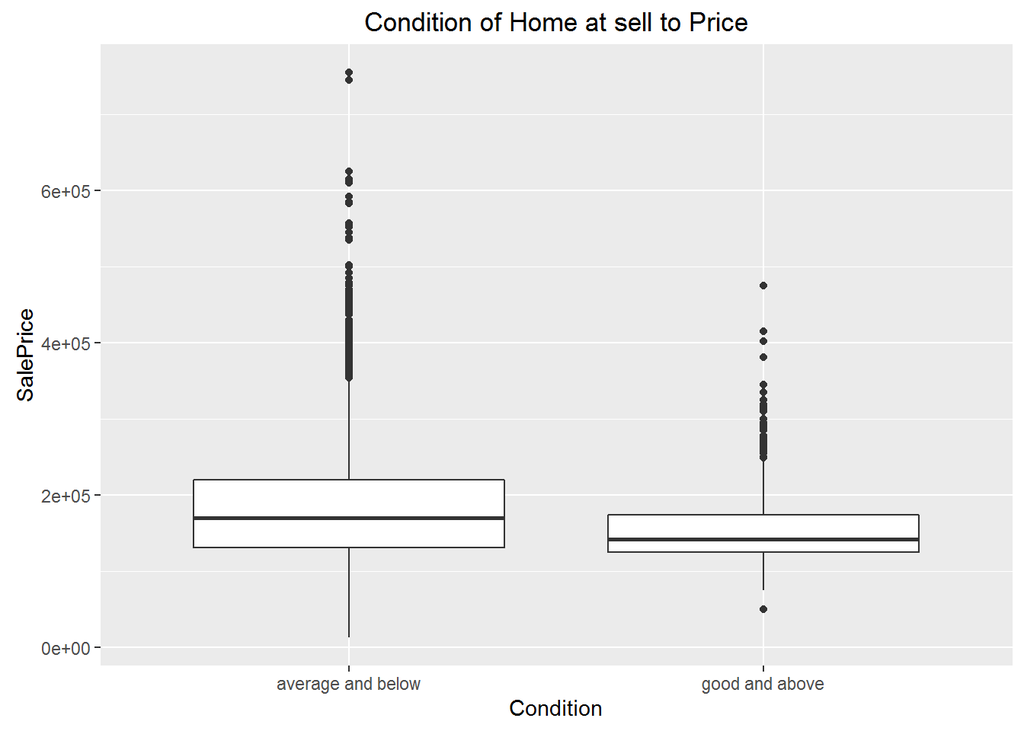

```r
plot5 <- ggplot(data, aes(Condition, SalePrice))
plot5 <- plot5 + geom_boxplot()
plot5 <- plot5 + xlab("Condition")
plot5 <- plot5 + ggtitle("Condition of Home at sell to Price")
plot5
```

Now, we can make a multiple regression model to represent statistical significance of the variables in regard to price.

```r
priceModel <- lm(SalePrice ~ Shape + Residential + Quality + Condition, data = data)
summary(priceModel)
```

```
##
## Call:
## lm(formula = SalePrice ~ Shape + Residential + Quality + Condition,
##     data = data)
##
## Residuals:
##     Min      1Q  Median      3Q     Max
## -166300  -34280   -4722   23198  491200
##
## Coefficients:
##                         Estimate Std. Error t value Pr(>|t|)
## (Intercept)               141875       5225  27.154  < 2e-16 ***
## Shaperegular              -25428       2324 -10.941  < 2e-16 ***
## Residentialresidential     17847       4757   3.752 0.000179 ***
## Qualitygood and above     104078       2378  43.775  < 2e-16 ***
## Conditiongood and above    -2486       2800  -0.888 0.374636
## ---
## Signif. codes:  0 '***' 0.001 '**' 0.01 '*' 0.05 '.' 0.1 ' ' 1
##
## Residual standard error: 58700 on 2925 degrees of freedom
## Multiple R-squared:  0.4608, Adjusted R-squared:   0.46
## F-statistic: 624.8 on 4 and 2925 DF,  p-value: < 2.2e-16
```

```r
p_value_int <- summary(priceModel)$coefficients[5,4]
p_value_int
```

```
## [1] 0.3746365
```

```r
priceCoef <- priceModel$coefficients
priceCoef
```

```
##             (Intercept)            Shaperegular  Residentialresidential
##              141874.964              -25427.985               17847.329
##   Qualitygood and above Conditiongood and above
##              104077.726               -2486.276
```

```r
fstat <- summary(priceModel)$fstatistic
fstat
```

```
##    value    numdf    dendf
##  624.813    4.000 2925.000
```

```r
priceModel_r2 <- round(summary(priceModel)$r.squared, digits = 2)*100
priceModel_r2
```

```
## [1] 46
```

The model shows a moderate positive correlation in for the variables in the multiple regression model.

The model shows a significant p-value for all values except Condition (p-value = 0.3746365), thus it must be removed in the next model. The F-statistic is on 624.81 on 4 to 2925. Additionally, this model has an r-squared value of 46%, which means that 46% of variance in the price of a home is accounted for by the shape, status of residential area of the lot, and quality of home, and the condition of the home at sell.

### Model 6: By condition of sale.

This model will define a variable which accounts for a home’s condition of sell. This variable can be considered in terms of the next owner acquires the home. In particular, the new variable will have 2 types of observations, “normal” and “other”. Where “normal” is the home being bought, and a possible example of “other” would be the home being bought between family members or perhaps the home is a partially finished home etc.

```r
condition_sale <- function(n)
{
  if (n == "Normal")
    return("normal")
  else
    return("other")
}
data$SaleCond <- sapply(data$Sale.Condition, condition_sale)
```

The model’s new variable, SaleCond, can now be plotted.

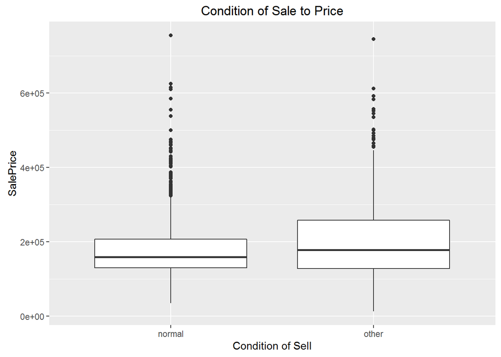

```r
plot6 <- ggplot(data, aes(SaleCond, SalePrice))
plot6 <- plot6 + geom_boxplot()
plot6 <- plot6 + xlab("Condition of Sell")
plot6 <- plot6 + ggtitle("Condition of Sale to Price")
plot6
```

Homes which were acquired through normal transactions had a lower mean selling price. Homes acquired through other forms of transactions were at a higher mean selling price.

Now, we can make a multiple regression model to represent statistical significance of the variables in regard to price.

```r
priceModel <- lm(SalePrice ~ Shape + Residential + Quality + SaleCond, data = data)
summary(priceModel)
```

```
##
## Call:
## lm(formula = SalePrice ~ Shape + Residential + Quality + SaleCond,
##     data = data)
##
## Residuals:
##     Min      1Q  Median      3Q     Max
## -166590  -33845   -4045   23595  494451
##
## Coefficients:
##                        Estimate Std. Error t value Pr(>|t|)
## (Intercept)              137644       5259  26.172  < 2e-16 ***
## Shaperegular             -25729       2313 -11.124  < 2e-16 ***
## Residentialresidential    19761       4747   4.163 3.23e-05 ***
## Qualitygood and above    103144       2347  43.954  < 2e-16 ***
## SaleCondother             14040       2872   4.889 1.07e-06 ***
## ---
## Signif. codes:  0 '***' 0.001 '**' 0.01 '*' 0.05 '.' 0.1 ' ' 1
##
## Residual standard error: 58470 on 2925 degrees of freedom
## Multiple R-squared:  0.465,  Adjusted R-squared:  0.4642
## F-statistic: 635.5 on 4 and 2925 DF,  p-value: < 2.2e-16
```

```r
#p_value_int <- summary(priceModel)$coefficients[5,4]
#p_value_int

priceCoef <- priceModel$coefficients
priceCoef
```

```
##            (Intercept)           Shaperegular Residentialresidential
##              137644.12              -25729.13               19760.82
##  Qualitygood and above          SaleCondother
##              103144.38               14040.43
```

```r
fstat <- summary(priceModel)$fstatistic
fstat
```

```
##    value    numdf    dendf
##  635.524    4.000 2925.000
```

```r
priceModel_r2 <- round(summary(priceModel)$r.squared, digits = 2)*100
priceModel_r2
```

```
## [1] 46
```

The model shows a moderate positive correlation in for the variables in the multiple regression model.

The model shows a significant p-value for all values. The F-statistic is on 635.52 on 4 to 2925. Additionally, this model has an r-squared value of 46%, which means that 46% of variance in the price of a home is accounted for by the shape, status of residential area of the lot, and quality of home, and the condition of sell for the home.

Current Linear Regression Equation: $\widehat{SalePrice} = (1.3764412\times 10^{5}) + (-2.572913\times 10^{4})*Shape + (1.976082\times 10^{4})*Residential + (1.0314438\times 10^{5})*Quality + (1.404043\times 10^{4})*SaleCond$

The previous model’s equation is extended with the new Quality coefficient. When SaleCond is 0 (“normal”), the mean price of a home is 1.376441210^{5}. When Quality is 1 (“other”), the mean price of a home is 1.516845510^{5}.

### Model 7: Homes with some special addition.

```r
data$Special.Add <- ifelse(grepl('[a-zA-Z]+', data$Misc.Feature), "special", "normal")
```

The model’s new variable, Special.Add, can now be plotted.

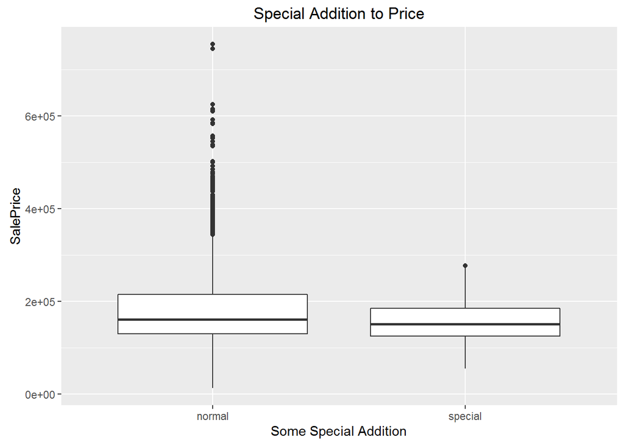

```r
plot7 <- ggplot(data, aes(Special.Add, SalePrice))
plot7 <- plot7 + geom_boxplot()
plot7 <- plot7 + xlab("Some Special Addition")
plot7 <- plot7 + ggtitle("Special Addition to Price")
plot7
```

Homes with a no special addition sold at a higher mean selling price, while homes with a special addition sold at a lower mean selling price.

Now, we can make a multiple regression model to represent statistical significance of the variables in regard to price.

```r
priceModel <- lm(SalePrice ~ Shape + Residential + Quality + SaleCond + Special.Add, data = data)
summary(priceModel)
```

```
##
## Call:
## lm(formula = SalePrice ~ Shape + Residential + Quality + SaleCond +
##     Special.Add, data = data)
##
## Residuals:
##     Min      1Q  Median      3Q     Max
## -166635  -33901   -3885   23623  494344
##
## Coefficients:
##                        Estimate Std. Error t value Pr(>|t|)
## (Intercept)              137856       5267  26.172  < 2e-16 ***
## Shaperegular             -25777       2314 -11.139  < 2e-16 ***
## Residentialresidential    19807       4747   4.172 3.11e-05 ***
## Qualitygood and above    102994       2355  43.727  < 2e-16 ***
## SaleCondother             13979       2874   4.865 1.21e-06 ***
## Special.Addspecial        -4354       5814  -0.749    0.454
## ---
## Signif. codes:  0 '***' 0.001 '**' 0.01 '*' 0.05 '.' 0.1 ' ' 1
##
## Residual standard error: 58480 on 2924 degrees of freedom
## Multiple R-squared:  0.4651, Adjusted R-squared:  0.4642
## F-statistic: 508.5 on 5 and 2924 DF,  p-value: < 2.2e-16
```

```r
p_value_int <- summary(priceModel)$coefficients[6,4]
p_value_int
```

```
## [1] 0.4539481
```

```r
priceCoef <- priceModel$coefficients
priceCoef
```

```
##            (Intercept)           Shaperegular Residentialresidential
##             137855.535             -25777.108              19806.706
##  Qualitygood and above          SaleCondother     Special.Addspecial
##             102994.180              13979.036              -4354.344
```

```r
fstat <- summary(priceModel)$fstatistic
fstat
```

```
##     value     numdf     dendf
##  508.4551    5.0000 2924.0000
```

```r
priceModel_r2 <- round(summary(priceModel)$r.squared, digits = 2)*100
priceModel_r2
```

```
## [1] 47
```

The model shows a moderate positive correlation in for the variables in the multiple regression model.

Current Linear Regression Equation: $\widehat{SalePrice} = (1.3785554\times 10^{5}) + (-2.577711\times 10^{4})*Shape + (1.980671\times 10^{4})*Residential + (1.0299418\times 10^{5})*Quality + (1.397904\times 10^{4})*SaleCond$

### Model 8: Homes with quality exteriors

This model will define a variable which accounts for a home’s exterior quality. The variable classifies observations with “quality” and “avg. to poor” values.

```r
ext_qual <- function(n)
{
  if (n == "Ex" || n == "Gd")
    return("quality")
  else
    return("avg. to poor")
}
data$Ext.Qual <- sapply(data$Exter.Qual, ext_qual)
```

The model’s new variable, Ext.Qual, can now be plotted.

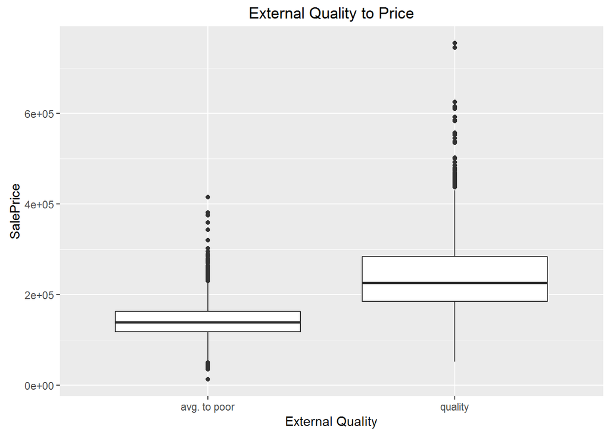

```r
plot8 <- ggplot(data, aes(Ext.Qual, SalePrice))
plot8 <- plot8 + geom_boxplot()
plot8 <- plot8 + xlab("External Quality")
plot8 <- plot8 + ggtitle("External Quality to Price")
plot8
```

Homes with an avg. to poor external quality sold at a lower price than those with quality external appearance.

Now, we can make a multiple regression model to represent statistical significance of the variables in regard to price.

```r
priceModel <- lm(SalePrice ~ Shape + Residential + Quality + SaleCond + Ext.Qual, data = data)
summary(priceModel)
```

```
##
## Call:
## lm(formula = SalePrice ~ Shape + Residential + Quality + SaleCond +
##     Ext.Qual, data = data)
##
## Residuals:
##     Min      1Q  Median      3Q     Max
## -148077  -33287   -3436   22961  485679
##
## Coefficients:
##                        Estimate Std. Error t value Pr(>|t|)
## (Intercept)              119991       5158  23.264  < 2e-16 ***
## Shaperegular             -21871       2230  -9.810  < 2e-16 ***
## Residentialresidential    29919       4592   6.515 8.54e-11 ***
## Qualitygood and above     69244       3077  22.502  < 2e-16 ***
## SaleCondother             11068       2759   4.012 6.17e-05 ***
## Ext.Qualquality           50167       3108  16.140  < 2e-16 ***
## ---
## Signif. codes:  0 '***' 0.001 '**' 0.01 '*' 0.05 '.' 0.1 ' ' 1
##
## Residual standard error: 56040 on 2924 degrees of freedom
## Multiple R-squared:  0.5087, Adjusted R-squared:  0.5079
## F-statistic: 605.6 on 5 and 2924 DF,  p-value: < 2.2e-16
```

```r
p_value_int <- summary(priceModel)$coefficients[6,4]
p_value_int
```

```
## [1] 3.314613e-56
```

```r
priceCoef <- priceModel$coefficients
priceCoef
```

```
##            (Intercept)           Shaperegular Residentialresidential
##              119991.38              -21871.45               29918.65
##  Qualitygood and above          SaleCondother        Ext.Qualquality
##               69243.96               11067.69               50167.44
```

```r
fstat <- summary(priceModel)$fstatistic
fstat
```

```
##     value     numdf     dendf
##  605.6308    5.0000 2924.0000
```

```r
priceModel_r2 <- round(summary(priceModel)$r.squared, digits = 2)*100
priceModel_r2
```

```
## [1] 51
```

This final multiple regression model shows a moderate positive correlation. This means that the mean price of a home is explained relatively well by these variables.

The model shows a significant p-value for all values. The F-statistic is on 605.63 on 5 to 2924. Additionally, this model has an r-squared value of 51%, which means that 51% of variance in the price of a home is accounted for by the shape, status of residential area of the lot, and quality of home, and the condition of sell for the home.

Current Linear Regression Equation: $\widehat{SalePrice} = (1.1999138\times 10^{5}) + (-2.187145\times 10^{4})*Shape + (2.991865\times 10^{4})*Residential + (6.924396\times 10^{4})*Quality + (1.106769\times 10^{4})*SaleCond + (5.016744\times 10^{4})*Ext.Qual$

The previous model’s equation is extended with the new Ext.Qual coefficient. When Ext.Qual is 0 (“avg. to poor”), the mean price of a home is 1.199913810^{5}. When Quality is 1 (“quality”), the mean price of a home is 1.701588210^{5}.